## INFS 772 Assignment 4

### Total 10 points (6 tasks)

### Mohammad Shafayet Jamil Hossain

# Image Classification with MNIST Dataset

This short introduction uses [Keras](https://www.tensorflow.org/guide/keras/overview) to:

1. Build a neural network that classifies images.
2. Train this neural network.
3. And, finally, evaluate the accuracy of the model.

Download and install TensorFlow 2. Import TensorFlow into your program:

Note: Upgrade `pip` to install the TensorFlow 2 package. See the [install guide](https://www.tensorflow.org/install) for details.

```python
import tensorflow as tf

from tensorflow.keras.datasets import mnist #from Keras download the mnist dataset
from tensorflow.keras.models import Sequential # import the sequential model
from tensorflow.keras.layers import Flatten
from tensorflow.keras.layers import Dense # import the Dense(Fully connected) layer
from tensorflow.keras.optimizers import RMSprop # import rmsprop optimizer
from tensorflow.keras.utils import to_categorical # prepare the labels
from tensorflow.keras.layers import  Conv2D, Dropout,  MaxPooling2D
import matplotlib.pyplot as plt #import plot as plt
```

```python
tf.__version__
```

```
'2.8.0'
```

Load and prepare the [MNIST dataset](http://yann.lecun.com/exdb/mnist/). Convert the samples from integers to floating-point numbers:

```python
mnist = tf.keras.datasets.mnist

(x_train, y_train), (x_test, y_test) = mnist.load_data()
x_train, x_test = x_train / 255.0, x_test / 255.0
```

Build the `tf.keras.Sequential` model by stacking layers. Choose an optimizer and loss function for training:

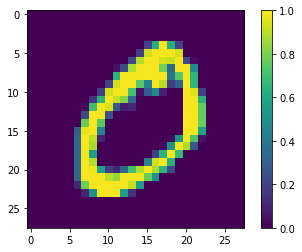

```python
import matplotlib.pyplot as plt
%matplotlib inline
plt.figure()
plt.imshow(x_train[1])
plt.colorbar()
plt.grid(False)
plt.show()
```

## Task 1: Build Neural Network Using the following code samples (2 points)

```
model = Sequential() # make our model Sequential

model.add(Flatten(input_shape=(28, 28)))
model.add(Dense(50, activation = "relu")) # add a hidden layer
model.add(Dense(10, activation = 'softmax')) # add an output layer
```

### Required Specification for the Hidden Layers

Dense 64 --> Dense 32

Total params: 52,650

```python
model = tf.keras.models.Sequential([
  tf.keras.layers.Flatten(input_shape=(28, 28)),
  tf.keras.layers.Dense(32, activation=tf.nn.relu),
  tf.keras.layers.Dropout(0.2),
  tf.keras.layers.Dense(10, activation=tf.nn.softmax)
])
```

```python
model.summary()
```

```
Model: "sequential_7"
_________________________________________________________________
 Layer (type)                Output Shape              Param #
=================================================================
 flatten_4 (Flatten)         (None, 784)               0

 dense_10 (Dense)            (None, 32)                25120

 dropout_4 (Dropout)         (None, 32)                0

 dense_11 (Dense)            (None, 10)                330

=================================================================
Total params: 25,450
Trainable params: 25,450
Non-trainable params: 0
_________________________________________________________________
```

The following cell is not required. Remove it if it doesn't work under your environment

```python
from IPython.display import SVG
from tensorflow.keras.utils import model_to_dot

SVG(model_to_dot(model, show_shapes= True, show_layer_names=True, dpi=65).create(prog='dot', format='svg'))
```

[output not shown]

[output not shown]

## Task 2: Test the Model Architecture (2 points)

All codes are provided and make sure they produce the expected outputs

```python
predictions = model(x_train[:1]).numpy()
predictions
```

```
array([[0.14032267, 0.08194471, 0.10186218, 0.07489455, 0.08682165,
        0.13166611, 0.08246943, 0.12381339, 0.08744963, 0.08875564]],
      dtype=float32)
```

```python
tf.nn.softmax(predictions).numpy()
```

```
array([[0.10408892, 0.09818639, 0.10016162, 0.0974966 , 0.09866641,
        0.10319176, 0.09823792, 0.1023846 , 0.09872839, 0.09885742]],
      dtype=float32)
```

Note: It is possible to bake this `tf.nn.softmax` in as the activation function for the last layer of the network. While this can make the model output more directly interpretable, this approach is discouraged as it's impossible to provide an exact and numerically stable loss calculation for all models when using a softmax output.

The `losses.SparseCategoricalCrossentropy` loss takes a vector of logits and a `True` index and returns a scalar loss for each example.

```python
loss_fn = tf.keras.losses.SparseCategoricalCrossentropy(from_logits=True)
```

This loss is equal to the negative log probability of the true class: It is zero if the model is sure of the correct class.

This untrained model gives probabilities close to random (1/10 for each class), so the initial loss should be close to `-tf.math.log(1/10) ~= 2.3`.

```python
loss_fn(y_train[:1], predictions).numpy()
```

```
2.2711663
```

## Task 3: Compile the Model (1 point)

```
# rmsprop optimizer
model.compile(optimizer = "rmsprop", loss = loss_fn, metrics=['accuracy'])

# Adam optimizer
model.compile(optimizer = "adam", loss = loss_fn, metrics=['accuracy'])
```

### Requirement: compile either rmsprop or adam

```python
# your codes here
model.compile(optimizer='adam',
              loss='sparse_categorical_crossentropy',
              metrics=['accuracy'])
```

## Task 4: Fit the Model (1 point)

### Requirement: 10 Epochs and save the outputs into history

The `Model.fit` method adjusts the model parameters to minimize the loss:

```python
# your codes here
model.fit(x_train, y_train, epochs=5)
model.evaluate(x_test, y_test)
```

```
[0.13874821364879608, 0.9560999870300293]
```

The `Model.evaluate` method checks the models performance, usually on a "[Validation-set](https://developers.google.com/machine-learning/glossary#validation-set)" or "[Test-set](https://developers.google.com/machine-learning/glossary#test-set)".

```python
model.evaluate(x_test,  y_test, verbose=2)
```

[output not shown]

[output not shown]

```python
history = model.fit(x_test,  y_test, validation_split=0.33, epochs=150, batch_size=10, verbose=0)
```

```python
print(history.history.keys())
```

```
dict_keys(['loss', 'accuracy', 'val_loss', 'val_accuracy'])
```

## Task 5: Visualize training loss and accuracy (1 point)

#### Codes are provided, make sure the outputs are displayed properly.

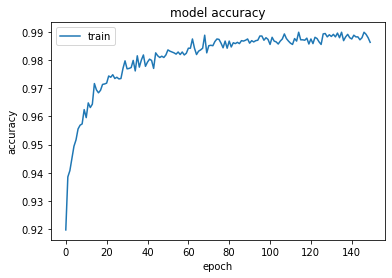

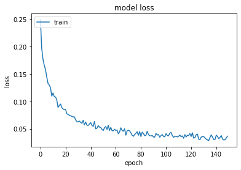

```python
import matplotlib.pyplot as plt

# summarize history for accuracy
plt.plot(history.history['accuracy'])

plt.title('model accuracy')
plt.ylabel('accuracy')
plt.xlabel('epoch')
plt.legend(['train', 'test'], loc='upper left')
plt.show()
# summarize history for loss
plt.plot(history.history['loss'])

plt.title('model loss')
plt.ylabel('loss')
plt.xlabel('epoch')
plt.legend(['train', 'test'], loc='upper left')
plt.show()
```

## Task 6: Build and train a simple CNN model and compare it with the Dense model (3 points)

### Build, train, and evaluate a simplle CNN model

### Reference: https://keras.io/examples/vision/mnist_convnet/ (2 points)

[Note] The CNN model architecture (and learning process configuration) can be idential to the one in the reference page.

```
Shape before encoding:  (60000,)
Shape after encoding:  (60000, 10)
```

[figure not shown]

[figure not shown]

```python
# keras imports for the dataset and building our neural network
from keras.datasets import mnist
from keras.models import Sequential
from keras.layers import Dense, Dropout, Conv2D, MaxPool2D, Flatten
from keras.utils import np_utils

# to calculate accuracy
from sklearn.metrics import accuracy_score

# loading the dataset
(X_train, y_train), (X_test, y_test) = mnist.load_data()

# building the input vector from the 28x28 pixels
X_train = X_train.reshape(X_train.shape[0], 28, 28, 1)
X_test = X_test.reshape(X_test.shape[0], 28, 28, 1)
X_train = X_train.astype('float32')
X_test = X_test.astype('float32')

# normalizing the data to help with the training
X_train /= 255
X_test /= 255

# encoding using keras' numpy-related utilities
n_classes = 10
print("Shape before encoding: ", y_train.shape)
Y_train = np_utils.to_categorical(y_train, n_classes)
Y_test = np_utils.to_categorical(y_test, n_classes)
print("Shape after encoding: ", Y_train.shape)

# building a linear stack of layers with the sequential model
model = Sequential()
# convolutional layer
model.add(Conv2D(25, kernel_size=(3,3), strides=(1,1), padding='valid', activation='relu', input_shape=(28,28,1)))
model.add(MaxPool2D(pool_size=(1,1)))
# flatten output of conv
model.add(Flatten())
# hidden layer
model.add(Dense(32, activation='relu'))
# output layer
model.add(Dense(10, activation='softmax'))

# compiling the sequential model
model.compile(loss='categorical_crossentropy', metrics=['accuracy'], optimizer='adam')

# training the model for 10 epochs
model.fit(X_train, Y_train, batch_size=128, epochs=10, validation_data=(X_test, Y_test))
import matplotlib.pyplot as plt

# summarize history for accuracy
plt.plot(history.history['accuracy'])

plt.title('model accuracy')
plt.ylabel('accuracy')
plt.xlabel('epoch')
plt.legend(['train', 'test'], loc='upper left')
plt.show()
# summarize history for loss
plt.plot(history.history['loss'])

plt.title('model loss')
plt.ylabel('loss')
plt.xlabel('epoch')
plt.legend(['train', 'test'], loc='upper left')
plt.show()
```